# Ozon E-Cup 2026 «Ценность пользователей поиска»

Предсказание суммарного GMV пользователя на 30 дней

HSE Бобры

## Команда

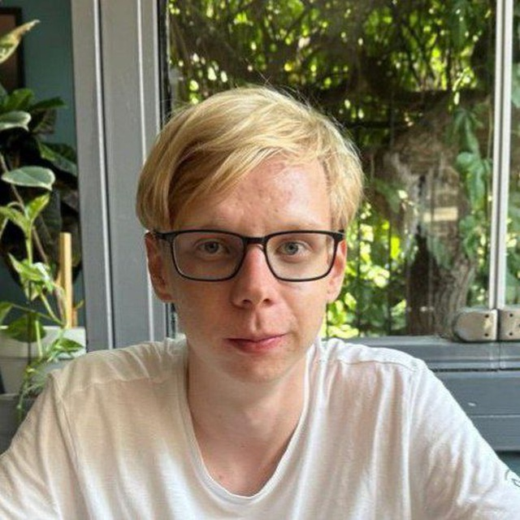

Алексей Карасев

НИУ ВШЭ · Rostics  
MLE

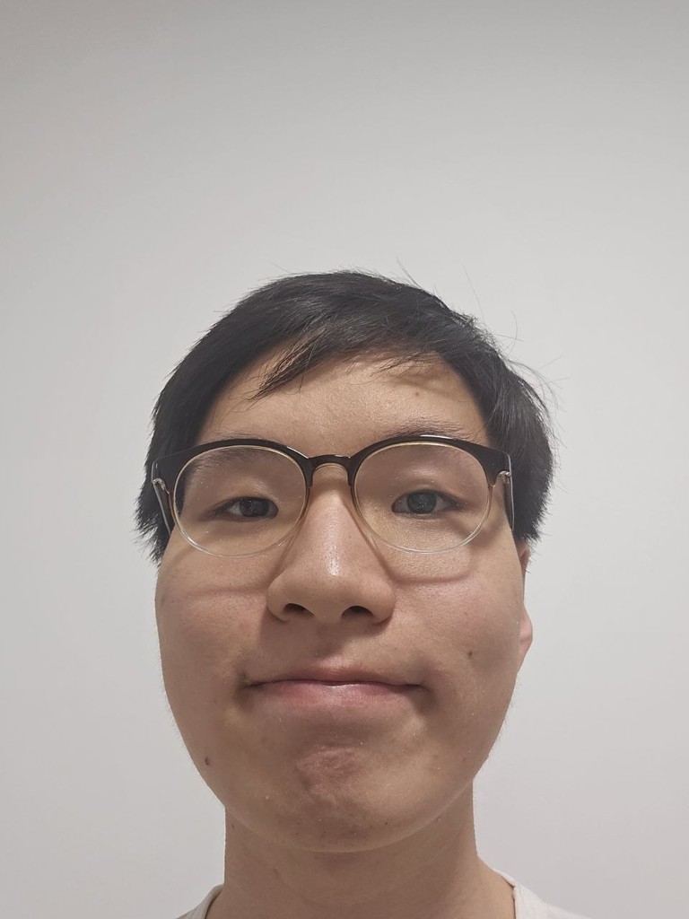

Джон Ким

НИУ ВШЭ  
ассистент по математике НИУ ВШЭ

[figure not shown]

Дмитрий Николаев

НИУ ВШЭ · ex-X5  
DE / DS

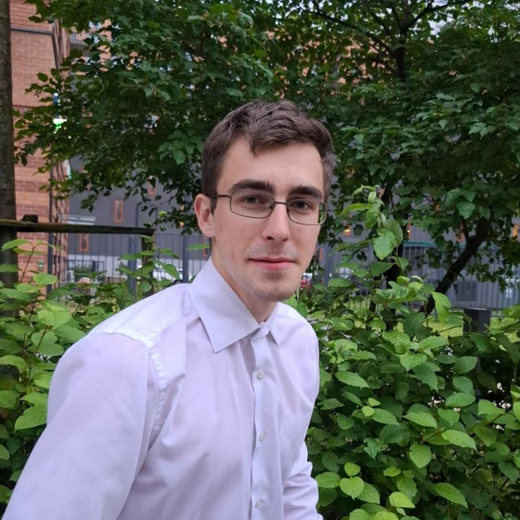

Максим Удовиченко

НИУ ВШЭ · Альфа-Банк  
DS

# Обзор задачи

## Что требуется предсказать

Суммарный GMV каждого пользователя за **30 дней**

| Параметр | Значение |
| --- | --- |
| История | 2025-01-01 … 2026-02-13 |
| Целевое окно | 2026-02-14 … 2026-03-15 |
| Пользователей | 250 000 |
| Записей | более 30 млн |
| Лидерборд | public 20% / private 80% |

Метрика — RMSLE, отрицательные предсказания зануляются:

$$\mathrm{RMSLE}=\sqrt{\frac{1}{n}\sum_i\bigl(\log(1+y_i)-\log(1+\max(0,\hat y_i))\bigr)^2}$$

Цель: долгосрочная оценка `LTV` пользователя через прогнозирование `GMV` на несколько недель вперед

# EDA

## Структура данных

Одна строка — один пользователь за один **активный** день. Полная таблица пользователь × день заполнена лишь на ~30%: нулевые дни добавили явно

Точные равенства:

- `gmv = gmv_search + gmv_cat`
- `to_cart = search_to_cart + cat_to_cart`
- `to_ord = search_to_ord + cat_to_ord`
- `search = [searches > 0]`

## Смещение выборки

- Ни у одного пользователя последняя активность не раньше **2026-01-15** — все 250 000 активны хотя бы раз в последние 30 дней.
- Ни один не появляется впервые позже **2025-12-15** — у всех минимум ~60 дней истории.
- Дневная аудитория растёт с 43 тыс. до 95 тыс., при этом GMV на активного (~8–9) и доля покупателей (~0.14–0.16) стационарны

Панель отобрана **по выживанию**, а не случайной выборкой. Ранние срезы беднее не потому, что площадка росла, а потому что так устроен отбор.

Практическое следствие: обучаться на «одном train/test» нельзя — характеристики среза зависят от того, где стоит отсечка.

## Уровень уходит, форма остаётся

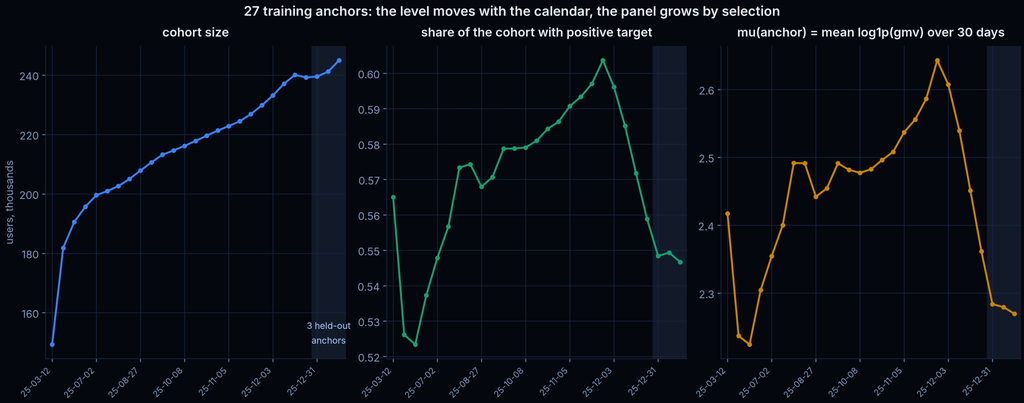

**Модели учат только форму, уровень моделируется отдельно.**

## Календарь: целевое окно ни на что не похоже

**Целевое окно 2026-02-14 … 2026-03-15 не совпадает ни с одним валидационным.** Тот же интервал год назад дал GMV на активного пользователя на **9.0% выше** предыдущих 30 дней — это 95-й процентиль обычного 30-дневного дрейфа (медиана +1.7%, p90 +6.8%). 14 и 23 февраля и 8 марта поднимают окно.

Отсюда два вывода, определившие всю архитектуру: **уровень нельзя брать с валидации**, и **сравнивать 30-дневные окна между собой без календарной поправки нельзя**.

# Идея решения

## Главные идеи

1. Разделить уровень и форму

$$y(\text{user},\ a) = \log(1+\mathrm{gmv}^{(30)}) - \mu(a), \qquad
\mu(a) = \overline{\log(1+\mathrm{gmv}^{(30)})}\ \text{по когорте якоря } a$$

Модели учат только кросс-секционную форму — она стабильна месяц к месяцу. Уровень $\mu$ предсказывается отдельно. Это самое важное структурное решение во всём проекте: оно снимает календарный дрейф с моделей и переносит его туда, где он измерим.

3. Ансамбль из разных источников смещения, а не разного шума 445 табличных признаков для деревьев и сетей плюс **сырой дневной тензор** для трансформеров — единственная пара источников, которая действительно читает данные по-разному.

4. Не переобучаемся под лидерборд Две константные пробы дают дисперсию и среднее публичного таргета точно. После этого каждый скор инвертируется в $\operatorname{Cov}(z,u)$, и финальный сабмит собирается алгеброй, а не подбором.

# Технологический стек

## Инструменты и инфраструктура

### Compute

- **Python 3.13**, зависимости и запуск — `uv`
- **polars** (в том числе lazy) на 30 млн строк, **numpy** + **numba** для оконных агрегатов
- **PyTorch 2.13** на CUDA: MLP, TabM, патч-трансформеры
- **CatBoost / LightGBM / XGBoost** — все на GPU
- **scipy**: `nnls` для весов блока, `ndtri` для rank-gauss
- **Optuna** — подбор гиперпараметров
- **SHAP** + **Captum** — интерпретация ансамбля и отдельных моделей

### Code Quality

- `ruff` (линт и формат), `ty` (типы), `taplo` (TOML), `markdownlint` (markdown)
- `pre-commit`: проверки приватных ключей, больших файлов

### Infrastructure

- **Monitoring**: MLflow-сервер с `MCP` сервером для управление контекстом модели об уже проведенных экспериментов
- **Feature storage**: файловое хранилище для признаков
- **AI-Driven ML development**: `Claude Code` для ускорения $\text{idea} \to \text{submit}$

# Описание решения

# Преимущества и недостатки

## Преимущества решения

**Постановка**

- Лосс на обучении совпадает с метрикой: RMSE по `log1p` — это и есть RMSLE. Никаких переводов между шкалами и связанных с ними потерь $\Rightarrow$ упрощает интерпретацию и принятие бизнесом решений
- Разделение уровня и формы делает решение устойчивым к календарному дрейфу

**Валидация**

**Интерпретируемость**

- Атрибуция на весь ансамбль, групповые пермутации, локальные waterfall по сегментам, проверка калибровки по вентилям.

## Недостатки решения

- **Тяжелый ансамбль**: долгое обучение и ресурсоъемкий инференс
- **Сложная воспроизводимость**: часть ансамбля обучается на прогнозах других моделей
- **Смещение выборки не устранено.** Модель обучена на панели «выживших». На реальном трафике доля неактивных и неплатящих выше, и уровень придётся перекалибровать заново.

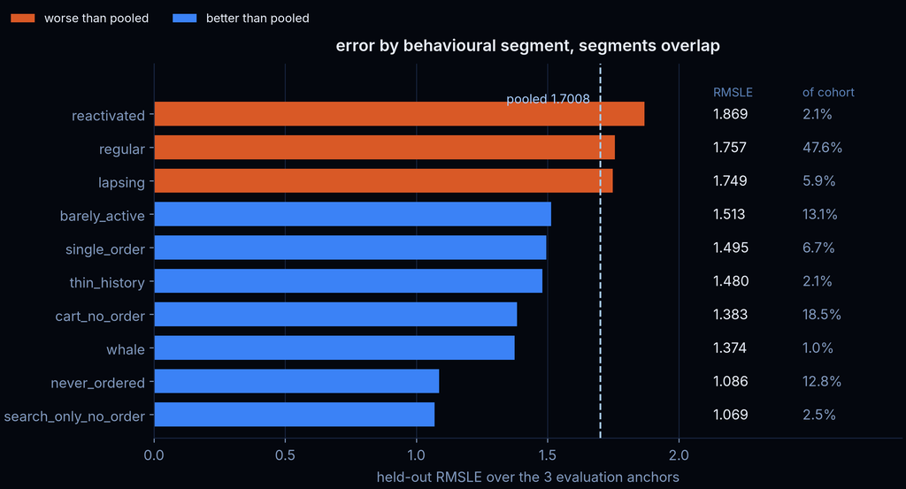

# Итоги

## Польза для бизнеса

**Применение**

- Калиброванный прогноз GMV на 30 дней: можно использовать для прогнозирования бизнес показателей
- Доверие бизнеса прогнозам за счет использования большого количества несколлерированных моделей в ансамбле
- A/B-тестирование изменение recsys’а и поиска: оценки вкладов поиска и recsys’a разделены на уровне признаков
- Прогнозы модели для персонализированных промо

**Развитие**

1. **Данные:** Категории, цены, регион, источник трафика, метаданные пользователя — позволит улучшить качество и интерпретируемость
2. **Переобучение без фильтра активности** — чтобы снять смещение выборки
3. **Упрощение** — “сглаживание” древовидной архитектуры ансамбля в линейный ансамбль

# Спасибо за внимание

**HSE Бобры** — Алексей Карасев, Джон Ким, Дмитрий Николаев, Максим Удовиченко

**Репозиторий**

[figure not shown]